# Maladaptive plastic responses of flowering time to geothermal heating (Cerastium 2)

Logger data preparation

Alicia Valdés

# Read list of all plants with temperature measured in 2018 (including Cerastium and other species)

|  | plot | id | species | plot_type | temp_term |
| --- | --- | --- | --- | --- | --- |
| 1 | H01 | H1 | cer | H | 19.7 |
| 2 | H01 | H3 | cer | H | 29.0 |
| 3 | H01 | H4 | cer | H | 20.0 |
| 4 | H01 | H5 | cer | H | 25.0 |
| 5 | H01 | H6 | cer | H | 27.5 |
| 6 | H01 | H7 | cer | H | 28.7 |

temp_term = soil temperature measured with a thermometer at the time of marking in 2018, measured next to each plant at a depth of 10 cm.

# Read list of plants with loggers (including Cerastium and other species)

|  | logger_nr | above_below | id | species | sunken |
| --- | --- | --- | --- | --- | --- |
| 1 | 3 | B | H1949 | bis | 0 |
| 2 | 18 | B | H1965 | bis | 0 |
| 3 | 20 | B | H1969 | bis | 0 |
| 4 | 21 | B | H1972 | bis | 0 |
| 5 | 28 | B | H1962 | bis | 0 |
| 6 | 51 | B | H1958 | bis | 0 |

# Merge both

Keeping records in both lists (i.e. plants with temperature measured with thermometer and with a logger).

|  | plot | id | species | plot_type | temp_term | logger_nr | above_below | sunken |
| --- | --- | --- | --- | --- | --- | --- | --- | --- |
| 1 | H01 | H1 | cer | H | 19.7 | 273 | A | 0 |
| 2 | H01 | H4 | cer | H | 20.0 | 266 | B | 0 |
| 3 | H01 | H13 | cer | H | 19.4 | 268 | B | 0 |
| 4 | H01 | H16 | cer | H | 20.4 | 267 | B | 0 |
| 5 | H01 | H17 | cer | H | 21.0 | 274 | A | 0 |
| 6 | H01 | H20 | cer | H | 15.0 | 270 | B | 0 |

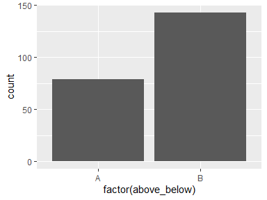

79 above and 143 below.

# Import raw iButton data

|  | datetime | logger_nr | temp | plot | id | species | plot_type | temp_term | above_below | sunken |
| --- | --- | --- | --- | --- | --- | --- | --- | --- | --- | --- |
| 1 | 2017-09-23 16:34:00 | 101 | 23.5 | HC1 | H848 | cer | C | 6.1 | B | 0 |
| 2 | 2017-09-23 19:34:00 | 101 | 23.5 | HC1 | H848 | cer | C | 6.1 | B | 0 |
| 3 | 2017-09-23 22:34:00 | 101 | 22.5 | HC1 | H848 | cer | C | 6.1 | B | 0 |
| 4 | 2017-09-24 01:34:00 | 101 | 20.0 | HC1 | H848 | cer | C | 6.1 | B | 0 |
| 5 | 2017-09-24 04:34:00 | 101 | 20.0 | HC1 | H848 | cer | C | 6.1 | B | 0 |
| 6 | 2017-09-24 07:34:00 | 101 | 19.5 | HC1 | H848 | cer | C | 6.1 | B | 0 |

```
[1] 70
```

There are some NAs for datetime (70 rows - it seems that they were not able to be converted to POSIXct) –> We can live with those

# Read coordinates of loggers and add to data:

|  | datetime | logger_nr | temp | plot | id | species | plot_type | temp_term | above_below | sunken | X | Y |
| --- | --- | --- | --- | --- | --- | --- | --- | --- | --- | --- | --- | --- |
| 1 | 2017-09-23 16:34:00 | 101 | 23.5 | HC1 | H848 | cer | C | 6.1 | B | 0 | 7.4 | 5.8 |
| 2 | 2017-09-23 19:34:00 | 101 | 23.5 | HC1 | H848 | cer | C | 6.1 | B | 0 | 7.4 | 5.8 |
| 3 | 2017-09-23 22:34:00 | 101 | 22.5 | HC1 | H848 | cer | C | 6.1 | B | 0 | 7.4 | 5.8 |
| 4 | 2017-09-24 01:34:00 | 101 | 20.0 | HC1 | H848 | cer | C | 6.1 | B | 0 | 7.4 | 5.8 |
| 5 | 2017-09-24 04:34:00 | 101 | 20.0 | HC1 | H848 | cer | C | 6.1 | B | 0 | 7.4 | 5.8 |
| 6 | 2017-09-24 07:34:00 | 101 | 19.5 | HC1 | H848 | cer | C | 6.1 | B | 0 | 7.4 | 5.8 |

# Plot locations of loggers in each plot, calculate distance matrices and make pairs

For each plot, pair each aboveground logger with the closest belowground logger

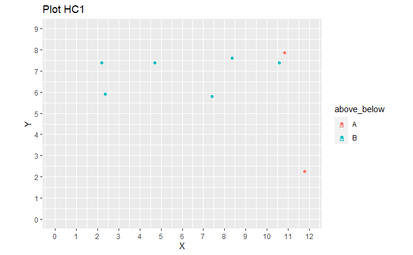

Distance matrix:

[output not shown]

Pairs: 103-105 and 104-101

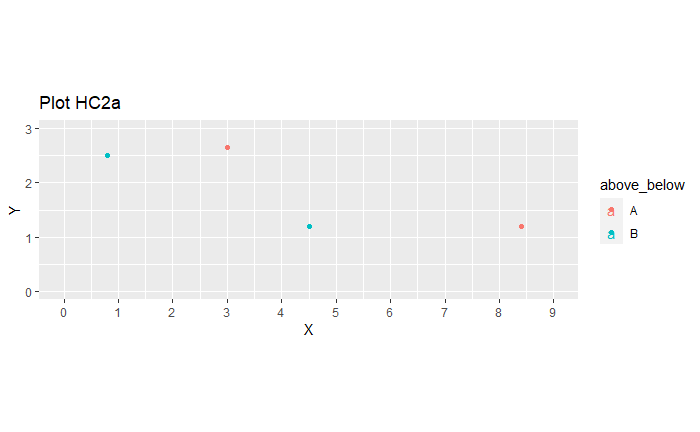

Distance matrix:

```
     108  111  113  115
108 0.00 3.92 2.21 7.71
111 3.92 0.00 2.09 3.90
113 2.21 2.09 0.00 5.59
115 7.71 3.90 5.59 0.00
```

Pairs: 108-113 and 111-115

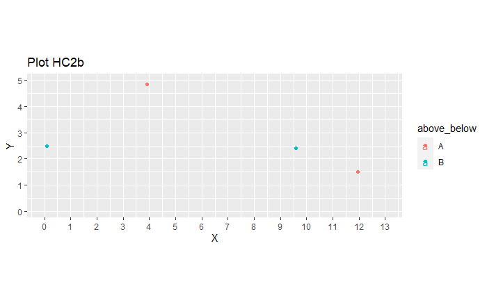

Distance matrix:

```
      117  119  122   123
117  0.00 9.50 4.47 11.89
119  9.50 0.00 6.20  2.52
122  4.47 6.20 0.00  8.72
123 11.89 2.52 8.72  0.00
```

Pairs: 122-117 and 119-123

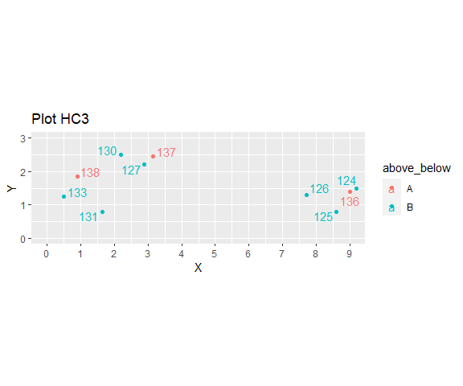

Distance matrix:

```
     124  125  126  127  130  131  133  136  137  138
124 0.00 0.92 1.51 6.34 7.07 7.58 8.70 0.22 6.12 8.31
125 0.92 0.00 1.03 5.87 6.62 6.95 8.11 0.72 5.69 7.77
126 1.51 1.03 0.00 4.88 5.63 6.07 7.20 1.30 4.69 6.82
127 6.34 5.87 4.88 0.00 0.76 1.88 2.58 6.15 0.35 2.03
130 7.07 6.62 5.63 0.76 0.00 1.79 2.11 6.89 0.95 1.45
131 7.58 6.95 6.07 1.88 1.79 0.00 1.23 7.37 2.23 1.29
133 8.70 8.11 7.20 2.58 2.11 1.23 0.00 8.50 2.91 0.72
136 0.22 0.72 1.30 6.15 6.89 7.37 8.50 0.00 5.94 8.11
137 6.12 5.69 4.69 0.35 0.95 2.23 2.91 5.94 0.00 2.33
138 8.31 7.77 6.82 2.03 1.45 1.29 0.72 8.11 2.33 0.00
```

Pairs: 137-127, 138-133 and 136-124

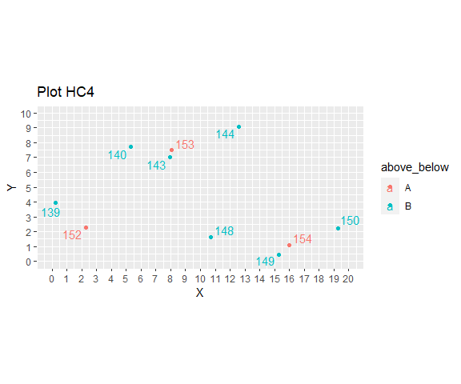

Distance matrix:

```
      139   140   143   144   148   149   150   152   153   154
139  0.00  6.29  8.28 13.38 10.70 15.45 19.13  2.63  8.57 16.01
140  6.29  0.00  2.74  7.43  8.11 12.35 15.02  6.18  2.76 12.57
143  8.28  2.74  0.00  5.10  6.02  9.85 12.30  7.35  0.51  9.98
144 13.38  7.43  5.10  0.00  7.69  9.06  9.58 12.34  4.82  8.69
148 10.70  8.11  6.02  7.69  0.00  4.75  8.62  8.43  6.42  5.33
149 15.45 12.35  9.85  9.06  4.75  0.00  4.39 13.13 10.11  0.96
150 19.13 15.02 12.30  9.58  8.62  4.39  0.00 17.00 12.41  3.49
152  2.63  6.18  7.35 12.34  8.43 13.13 17.00  0.00  7.75 13.75
153  8.57  2.76  0.51  4.82  6.42 10.11 12.41  7.75  0.00 10.21
154 16.01 12.57  9.98  8.69  5.33  0.96  3.49 13.75 10.21  0.00
```

Pairs: 139-152, 143-153 and 149-154

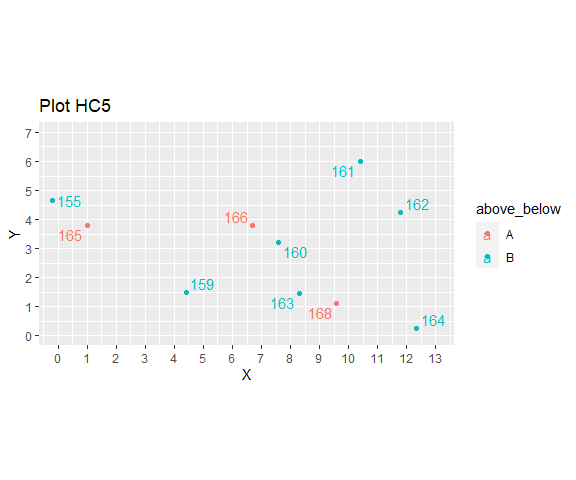

Distance matrix:

```
      155  159  160   161   162  163   164   165  166   168
155  0.00 5.58 7.93 10.69 12.01 9.08 13.30  1.47 6.95 10.42
159  5.58 0.00 3.62  7.50  7.89 3.90  8.05  4.10 3.25  5.22
160  7.93 3.62 0.00  3.96  4.33 1.88  5.59  6.63 1.08  2.90
161 10.69 7.50 3.96  0.00  2.24 5.01  6.07  9.65 4.30  4.96
162 12.01 7.89 4.33  2.24  0.00 4.48  4.04 10.81 5.12  3.84
163  9.08 3.90 1.88  5.01  4.48 0.00  4.22  7.67 2.84  1.35
164 13.30 8.05 5.59  6.07  4.04 4.22  0.00 11.89 6.67  2.88
165  1.47 4.10 6.63  9.65 10.81 7.67 11.89  0.00 5.70  9.01
166  6.95 3.25 1.08  4.30  5.12 2.84  6.67  5.70 0.00  3.96
168 10.42 5.22 2.90  4.96  3.84 1.35  2.88  9.01 3.96  0.00
```

Pairs: 165-155, 166-160 and 168-163

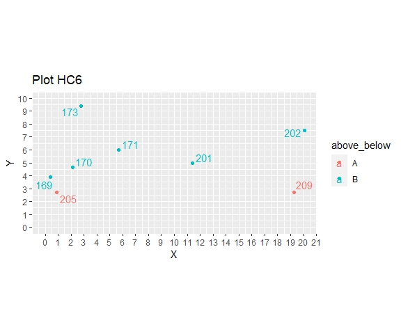

Distance matrix:

```
      169   170   171   173   201   202   205   209
169  0.00  1.86  5.70  6.00 11.05 20.03  1.30 18.94
170  1.86  0.00  3.84  4.80  9.30 18.22  2.29 17.31
171  5.70  3.84  0.00  4.47  5.80 14.48  5.82 13.99
173  6.00  4.80  4.47  0.00  9.68 17.40  6.96 17.81
201 11.05  9.30  5.80  9.68  0.00  9.07 10.74  8.21
202 20.03 18.22 14.48 17.40  9.07  0.00 19.79  4.87
205  1.30  2.29  5.82  6.96 10.74 19.79  0.00 18.40
209 18.94 17.31 13.99 17.81  8.21  4.87 18.40  0.00
```

Pairs: 205-169 and 209-202

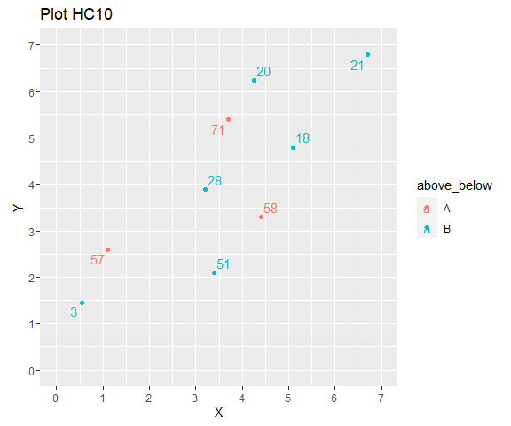

Distance matrix:

```
      3   18   20   21   28   51   57   58   71
3  0.00 5.65 6.06 8.15 3.61 2.92 1.27 4.27 5.05
18 5.65 0.00 1.68 2.56 2.10 3.19 4.57 1.66 1.52
20 6.06 1.68 0.00 2.51 2.57 4.24 4.82 2.95 1.01
21 8.15 2.56 2.51 0.00 4.55 5.74 7.00 4.19 3.31
28 3.61 2.10 2.57 4.55 0.00 1.81 2.47 1.34 1.58
51 2.92 3.19 4.24 5.74 1.81 0.00 2.35 1.56 3.31
57 1.27 4.57 4.82 7.00 2.47 2.35 0.00 3.37 3.82
58 4.27 1.66 2.95 4.19 1.34 1.56 3.37 0.00 2.21
71 5.05 1.52 1.01 3.31 1.58 3.31 3.82 2.21 0.00
```

Pairs: 57-3, 71-20 and 58-28

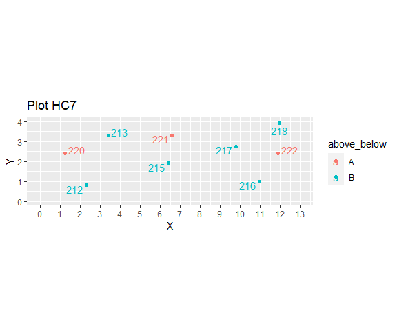

Distance matrix:

```
      212  213  215  216  217   218   220  221   222
212  0.00 2.73 4.24 8.65 7.75 10.14  1.91 4.97  9.73
213  2.73 0.00 3.31 7.89 6.42  8.57  2.33 3.20  8.55
215  4.24 3.31 0.00 4.64 3.50  5.90  5.17 1.41  5.52
216  8.65 7.89 4.64 0.00 2.09  3.07  9.80 4.92  1.69
217  7.75 6.42 3.50 2.09 0.00  2.44  8.56 3.25  2.13
218 10.14 8.57 5.90 3.07 2.44  0.00 10.80 5.38  1.50
220  1.91 2.33 5.17 9.80 8.56 10.80  0.00 5.43 10.65
221  4.97 3.20 1.41 4.92 3.25  5.38  5.43 0.00  5.38
222  9.73 8.55 5.52 1.69 2.13  1.50 10.65 5.38  0.00
```

Pairs: 220-212, 221-215 and 222-218

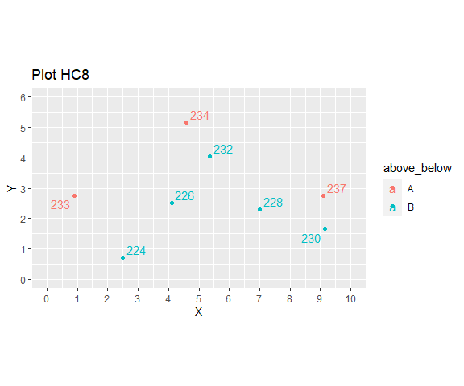

Distance matrix:

```
     224  226  228  230  232  233  234  237
224 0.00 2.41 4.78 6.72 4.40 2.60 4.92 6.91
226 2.41 0.00 2.91 5.12 1.99 3.21 2.70 5.01
228 4.78 2.91 0.00 2.25 2.41 6.12 3.73 2.15
230 6.72 5.12 2.25 0.00 4.49 8.32 5.74 1.10
232 4.40 1.99 2.41 4.49 0.00 4.64 1.33 3.97
233 2.60 3.21 6.12 8.32 4.64 0.00 4.41 8.20
234 4.92 2.70 3.73 5.74 1.33 4.41 0.00 5.10
237 6.91 5.01 2.15 1.10 3.97 8.20 5.10 0.00
```

Pairs: 233-224, 234-232 and 237-230

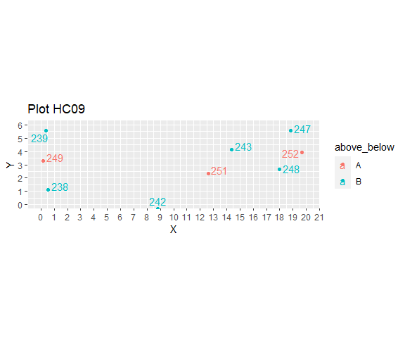

Distance matrix:

```
      238   239   242   243   247   248   249   251   252
238  0.00  4.50  8.37 14.18 18.83 17.52  2.24 12.11 19.36
239  4.50  0.00 10.26 14.07 18.45 17.85  2.31 12.63 19.37
242  8.37 10.26  0.00  7.15 11.63  9.66  9.37  4.63 11.70
243 14.18 14.07  7.15  0.00  4.67  3.90 14.28  2.55  5.30
247 18.83 18.45 11.63  4.67  0.00  3.02 18.83  7.02  1.81
248 17.52 17.85  9.66  3.90  3.02  0.00 17.86  5.41  2.14
249  2.24  2.31  9.37 14.28 18.83 17.86  0.00 12.49 19.56
251 12.11 12.63  4.63  2.55  7.02  5.41 12.49  0.00  7.28
252 19.36 19.37 11.70  5.30  1.81  2.14 19.56  7.28  0.00
```

Pairs: 249-238, 251-243 and 252-247

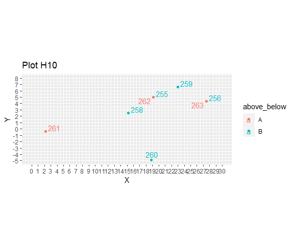

Distance matrix:

```
      255   256   258   259   260   261   262   263
255  0.00  8.43  4.63  4.22  9.85 17.74  0.00  8.43
256  8.43  0.00 12.44  5.03 12.66 25.74  8.43  0.00
258  4.63 12.44  0.00  8.81  8.18 13.32  4.63 12.44
259  4.22  5.03  8.81  0.00 12.20 21.95  4.22  5.03
260  9.85 12.66  8.18 12.20  0.00 17.19  9.85 12.66
261 17.74 25.74 13.32 21.95 17.19  0.00 17.74 25.74
262  0.00  8.43  4.63  4.22  9.85 17.74  0.00  8.43
263  8.43  0.00 12.44  5.03 12.66 25.74  8.43  0.00
```

Pairs: 261-258, 262-255 (same plant/location), 263-256 (same plant/location)

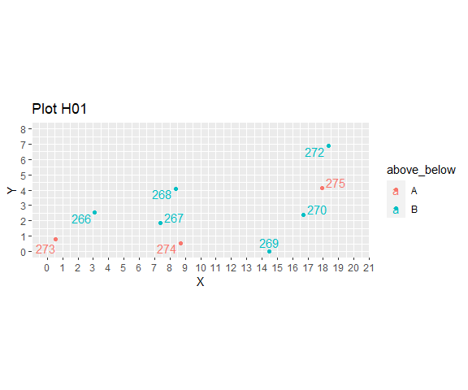

Distance matrix:

```
      266   267   268   269   270   272   273   274   275
266  0.00  4.36  5.52 11.68 13.60 15.86  3.09  5.95 14.94
267  4.36  0.00  2.46  7.34  9.32 12.06  6.93  1.84 10.80
268  5.52  2.46  0.00  7.35  8.47 10.34  8.52  3.56  9.55
269 11.68  7.34  7.35  0.00  3.26  7.90 13.97  5.83  5.40
270 13.60  9.32  8.47  3.26  0.00  4.79 16.23  8.21  2.15
272 15.86 12.06 10.34  7.90  4.79  0.00 18.82 11.55  2.78
273  3.09  6.93  8.52 13.97 16.23 18.82  0.00  8.15 17.72
274  5.95  1.84  3.56  5.83  8.21 11.55  8.15  0.00  9.93
275 14.94 10.80  9.55  5.40  2.15  2.78 17.72  9.93  0.00
```

Pairs: 273-266, 274-267 and 275-270

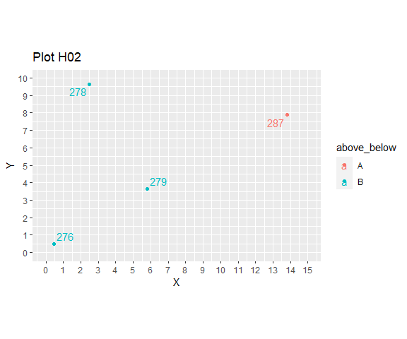

Distance matrix:

```
      276   278  279   287
276  0.00  9.38 6.21 15.26
278  9.38  0.00 6.85 11.43
279  6.21  6.85 0.00  9.06
287 15.26 11.43 9.06  0.00
```

Pairs: 287-279

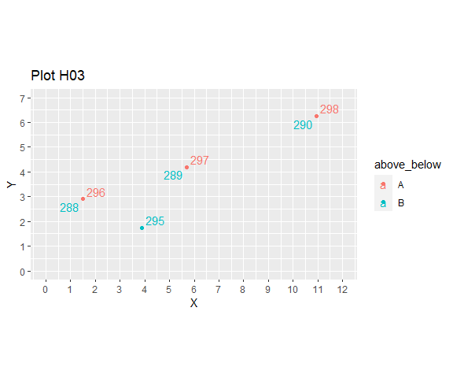

Distance matrix:

```
      288  289   290  295   296  297   298
288  0.00 4.40 10.03 2.66  0.00 4.40 10.03
289  4.40 0.00  5.64 3.04  4.40 0.00  5.64
290 10.03 5.64  0.00 8.36 10.03 5.64  0.00
295  2.66 3.04  8.36 0.00  2.66 3.04  8.36
296  0.00 4.40 10.03 2.66  0.00 4.40 10.03
297  4.40 0.00  5.64 3.04  4.40 0.00  5.64
298 10.03 5.64  0.00 8.36 10.03 5.64  0.00
```

Pairs: 296-288, 297-289 and 298-290 (same locations/plants)

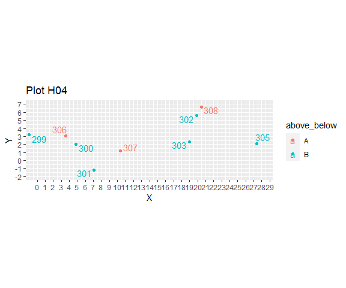

Distance matrix:

```
      299   300   301   302   303   305   306   307   308
299  0.00  5.92  9.22 21.04 20.02 28.37  4.55 11.52 21.73
300  5.92  0.00  3.94 15.52 14.20 22.55  1.67  5.61 16.33
301  9.22  3.94  0.00 14.49 12.42 20.52  5.58  4.04 15.49
302 21.04 15.52 14.49  0.00  3.37  8.23 16.54 10.51  1.19
303 20.02 14.20 12.42  3.37  0.00  8.35 15.47  8.73  4.54
305 28.37 22.55 20.52  8.23  8.35  0.00 23.82 17.02  8.27
306  4.55  1.67  5.58 16.54 15.47 23.82  0.00  7.06 17.27
307 11.52  5.61  4.04 10.51  8.73 17.02  7.06  0.00 11.48
308 21.73 16.33 15.49  1.19  4.54  8.27 17.27 11.48  0.00
```

Pairs: 306-300, 307-301 and 308-302

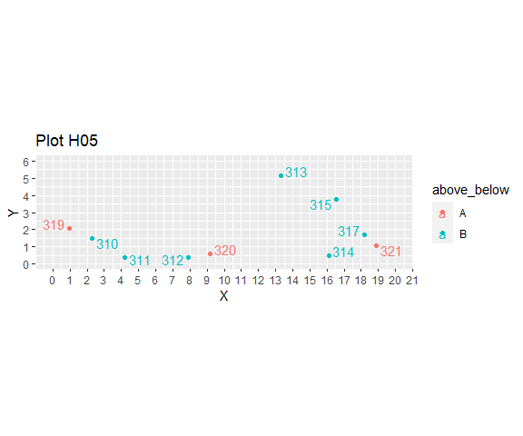

Distance matrix:

```
      310   311   312   313   314   315   317   319  320   321
310  0.00  2.20  5.71 11.59 13.84 14.43 15.90  1.46 6.96 16.61
311  2.20  0.00  3.70 10.27 11.90 12.80 14.06  3.64 5.00 14.71
312  5.71  3.70  0.00  7.19  8.20  9.28 10.38  7.14 1.32 11.02
313 11.59 10.27  7.19  0.00  5.43  3.54  5.99 12.73 6.12  6.94
314 13.84 11.90  8.20  5.43  0.00  3.28  2.42 15.23 6.90  2.85
315 14.43 12.80  9.28  3.54  3.28  0.00  2.63 15.69 8.00  3.58
317 15.90 14.06 10.38  5.99  2.42  2.63  0.00 17.25 9.07  0.96
319  1.46  3.64  7.14 12.73 15.23 15.69 17.25  0.00 8.38 17.98
320  6.96  5.00  1.32  6.12  6.90  8.00  9.07  8.38 0.00  9.71
321 16.61 14.71 11.02  6.94  2.85  3.58  0.96 17.98 9.71  0.00
```

Pairs: 319-310, 320-312 and 321-317

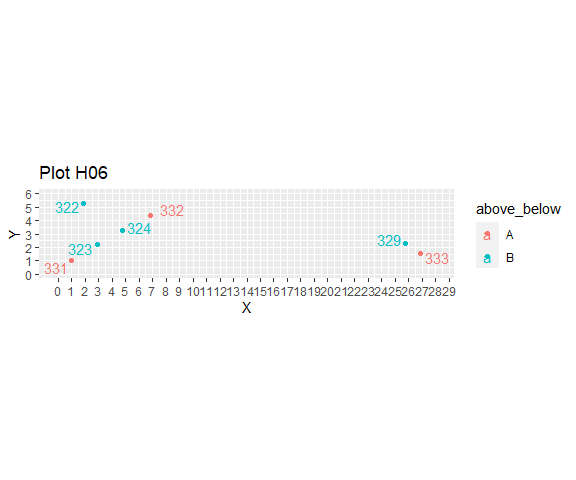

Distance matrix:

```
      322   323   324   329   331   332   333
322  0.00  3.26  3.51 24.09  4.39  5.03 25.23
323  3.26  0.00  2.13 22.90  2.25  4.52 23.96
324  3.51  2.13  0.00 21.07  4.37  2.39 22.17
329 24.09 22.90 21.07  0.00 24.83 19.07  1.29
331  4.39  2.25  4.37 24.83  0.00  6.77 25.86
332  5.03  4.52  2.39 19.07  6.77  0.00 20.20
333 25.23 23.96 22.17  1.29 25.86 20.20  0.00
```

Pairs: 331-323, 332-324 and 333-329

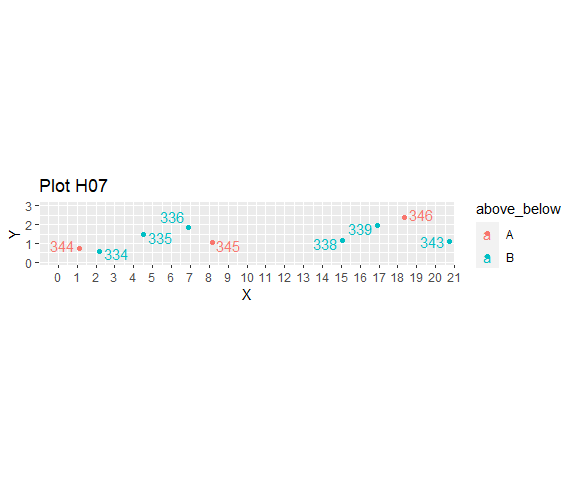

Distance matrix:

```
      334   335   336   338   339   343   344   345   346
334  0.00  2.45  4.86 12.86 14.76 18.56  1.11  5.97 16.25
335  2.45  0.00  2.43 10.55 12.41 16.25  3.47  3.67 13.88
336  4.86  2.43  0.00  8.18 10.00 13.87  5.90  1.48 11.46
338 12.86 10.55  8.18  0.00  2.02  5.70 13.96  6.90  3.53
339 14.76 12.41 10.00  2.02  0.00  3.94 15.85  8.80  1.52
343 18.56 16.25 13.87  5.70  3.94  0.00 19.65 12.60  2.73
344  1.11  3.47  5.90 13.96 15.85 19.65  0.00  7.06 17.33
345  5.97  3.67  1.48  6.90  8.80 12.60  7.06  0.00 10.29
346 16.25 13.88 11.46  3.53  1.52  2.73 17.33 10.29  0.00
```

Pairs: 344-334, 345-336 and 346-339

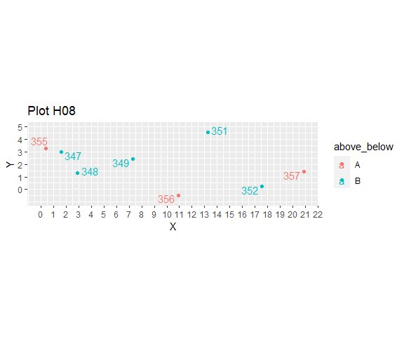

Distance matrix:

```
      347   348   349   351   352   355   356   357
347  0.00  2.10  5.73 11.76 16.18  1.24  9.90 19.36
348  2.10  0.00  4.54 10.85 14.69  3.17  8.19 18.00
349  5.73  4.54  0.00  6.33 10.47  6.95  4.59 13.64
351 11.76 10.85  6.33  0.00  6.08 12.92  5.52  8.27
352 16.18 14.69 10.47  6.08  0.00 17.41  6.69  3.54
355  1.24  3.17  6.95 12.92 17.41  0.00 11.13 20.58
356  9.90  8.19  4.59  5.52  6.69 11.13  0.00 10.17
357 19.36 18.00 13.64  8.27  3.54 20.58 10.17  0.00
```

Pairs: 355-347, 356-349 and 357-352

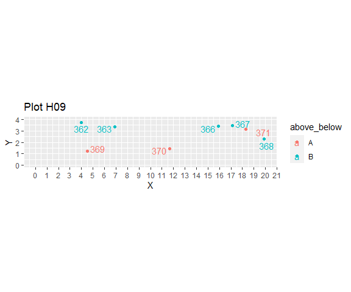

Distance matrix:

```
      362   363   366   367   368   369  370   371
362  0.00  2.93 11.91 13.15 15.97  2.55 7.99 14.31
363  2.93  0.00  9.00 10.25 13.04  3.19 5.12 11.40
366 11.91  9.00  0.00  1.25  4.15 11.60 4.68  2.41
367 13.15 10.25  1.25  0.00  2.98 12.84 5.85  1.19
368 15.97 13.04  4.15  2.98  0.00 15.44 8.29  1.81
369  2.55  3.19 11.60 12.84 15.44  0.00 7.15 13.93
370  7.99  5.12  4.68  5.85  8.29  7.15 0.00  6.86
371 14.31 11.40  2.41  1.19  1.81 13.93 6.86  0.00
```

Pairs: 369-362, 370-366 and 371-367

Plot H11 not included because there are only aboveground loggers

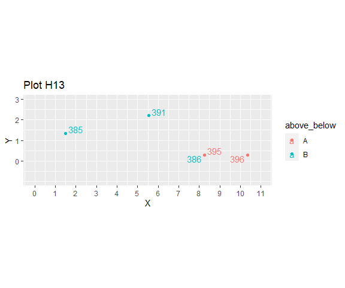

Distance matrix:

```
     385  386  391  395  396
385 0.00 6.83 4.14 6.83 8.91
386 6.83 0.00 3.30 0.00 2.10
391 4.14 3.30 0.00 3.30 5.16
395 6.83 0.00 3.30 0.00 2.10
396 8.91 2.10 5.16 2.10 0.00
```

Pairs: 395-386 (same location/plant) and 396-391

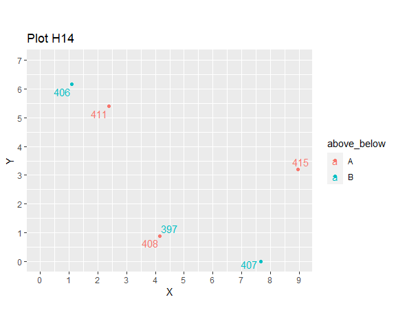

Distance matrix:

```
     397  406  407  408  411  415
397 0.00 6.07 3.61 0.00 4.83 5.32
406 6.07 0.00 8.98 6.07 1.50 8.39
407 3.61 8.98 0.00 3.61 7.53 3.45
408 0.00 6.07 3.61 0.00 4.83 5.32
411 4.83 1.50 7.53 4.83 0.00 6.91
415 5.32 8.39 3.45 5.32 6.91 0.00
```

Pairs: 411-406, 408-397 and 415-407

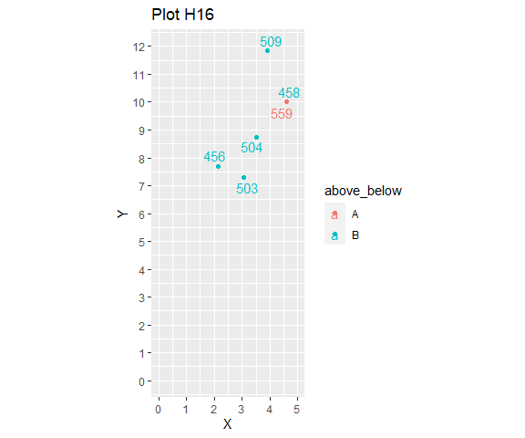

Distance matrix:

```
     456  458  503  504  509  559
456 0.00 3.36 0.98 1.71 4.50 3.36
458 3.36 0.00 3.11 1.67 1.98 0.00
503 0.98 3.11 0.00 1.52 4.63 3.11
504 1.71 1.67 1.52 0.00 3.13 1.67
509 4.50 1.98 4.63 3.13 0.00 1.98
559 3.36 0.00 3.11 1.67 1.98 0.00
```

Pairs: 458-559

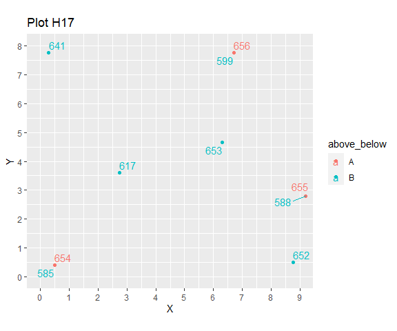

Distance matrix:

```
     585   588  599  617   641   652  653  654   655  656
585 0.00  9.02 9.62 3.91  7.35  8.25 7.19 0.00  9.02 9.62
588 9.02  0.00 5.55 6.50 10.18  2.34 3.44 9.02  0.00 5.55
599 9.62  5.55 0.00 5.73  6.40  7.53 3.13 9.62  5.55 0.00
617 3.91  6.50 5.73 0.00  4.82  6.75 3.70 3.91  6.50 5.73
641 7.35 10.18 6.40 4.82  0.00 11.13 6.75 7.35 10.18 6.40
652 8.25  2.34 7.53 6.75 11.13  0.00 4.82 8.25  2.34 7.53
653 7.19  3.44 3.13 3.70  6.75  4.82 0.00 7.19  3.44 3.13
654 0.00  9.02 9.62 3.91  7.35  8.25 7.19 0.00  9.02 9.62
655 9.02  0.00 5.55 6.50 10.18  2.34 3.44 9.02  0.00 5.55
656 9.62  5.55 0.00 5.73  6.40  7.53 3.13 9.62  5.55 0.00
```

Pairs: 654-585, 655-588 and 656-599 (all same locations / plants)

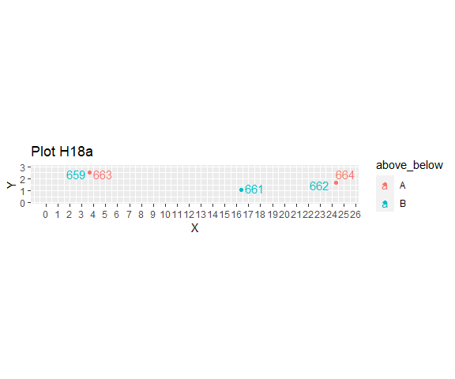

Distance matrix:

[output not shown]

Pairs: 663-659 and 664-662 (all same locations / plants)

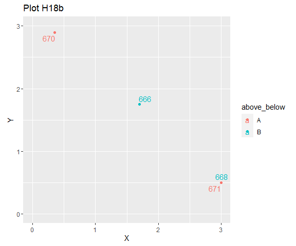

Distance matrix:

```
     666  668  670  671
666 0.00 1.80 1.77 1.80
668 1.80 0.00 3.58 0.00
670 1.77 3.58 0.00 3.58
671 1.80 0.00 3.58 0.00
```

Pairs: 671-668 (same location / plant) and 670-666

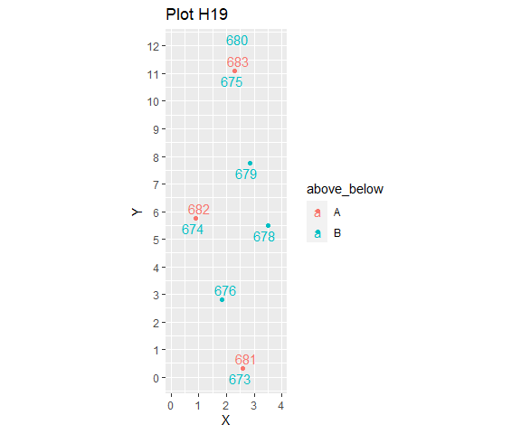

Distance matrix:

[output not shown]

Pairs: 683-675, 682-674, 681-673 (all same locations / plants)

# Write logger_data and logger_data_pairs to csv files